# Time Series Forecasting - Quiz 2 - Solution Notebook

```python
import pandas as pd
import numpy as np
import seaborn as sns
from matplotlib import pyplot as plt
import matplotlib
import statsmodels
import sklearn
```

```python
print('Pandas version:',pd.__version__)
print('Numpy version:',np.__version__)
print('Seaborn version:',sns.__version__)
print('Matplotlib version:',matplotlib.__version__)
print('Statsmodels version:',statsmodels.__version__)
print('Sklearn version:',sklearn.__version__)
```

```
Pandas version: 1.0.5
Numpy version: 1.19.0
Seaborn version: 0.10.1
Matplotlib version: 3.2.1
Statsmodels version: 0.11.1
Sklearn version: 0.23.1
```

```python
import os
os.chdir('D:/Academic Operations/DSBA - Python/Online/Time Series Forecasting/Assessments/Quiz 2')
```

# Q4. Read the data and plot a monthly Time Series plot of 'CO2 Emission'.

```python
df = pd.read_csv('Emission.csv', parse_dates = ['Year-Month'], index_col = 'Year-Month')
df.head()
```

| Year-Month | CO2 Emission |
| --- | --- |
| 1973-01-01 | 106.363 |
| 1973-02-01 | 101.760 |
| 1973-03-01 | 110.553 |
| 1973-04-01 | 104.734 |
| 1973-05-01 | 114.897 |

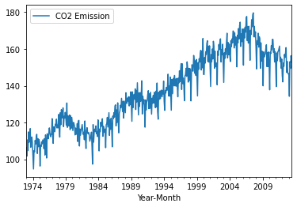

```python
df.plot();
```

## Split the data into train and test. The training data should contain 80% of the full data and the test data should contain the most recent 20% of the full data.

```python
train    =   df[0:int(len(df)*0.8)]
test     =   df[int(len(df)*0.8):]
```

```python
print(train.head(),'\n')
print(train.tail())
```

```
            CO2 Emission
Year-Month
1973-01-01       106.363
1973-02-01       101.760
1973-03-01       110.553
1973-04-01       104.734
1973-05-01       114.897

            CO2 Emission
Year-Month
2004-12-01       166.619
2005-01-01       161.372
2005-02-01       150.283
2005-03-01       167.523
2005-04-01       163.376
```

```python
print(test.head(),'\n')
print(test.tail())
```

```
            CO2 Emission
Year-Month
2005-05-01       171.070
2005-06-01       165.419
2005-07-01       172.746
2005-08-01       174.577
2005-09-01       161.380

            CO2 Emission
Year-Month
2013-02-01       134.243
2013-03-01       153.078
2013-04-01       149.442
2013-05-01       156.356
2013-06-01       152.814
```

# Q5. Build a Simple Exponential Smoothing model [when using the '.fit' command, please do make sure that the parameter is optimized=True] and calculate the Root Mean Squared Error on the test data.

```python
from statsmodels.tsa.holtwinters import SimpleExpSmoothing, Holt, ExponentialSmoothing
```

```python
from sklearn.metrics import mean_squared_error
```

```python
pred_opt   =  SimpleExpSmoothing(train).fit(optimized = True)

print('')
print('== Simple Exponential Smoothing ')
print('')

print('')
print('Smoothing Level', np.round(pred_opt.params['smoothing_level'], 4))
print('Initial Level',   np.round(pred_opt.params['initial_level'], 4))
print('')

y_pred_opt           = pred_opt.forecast(steps = len(test['CO2 Emission']))

rmse_opt             =  mean_squared_error(test['CO2 Emission'], y_pred_opt,squared=False)

print('RMSE on the Test Set:',rmse_opt)
```

```
== Simple Exponential Smoothing


Smoothing Level 0.1784
Initial Level 107.8943

RMSE on the Test Set: 9.922370664614252
```

# Q6. Build a Double Exponential Smoothing model [when using the '.fit' command, please do make sure that the parameter is optimized=True] and calculate the Root Mean Squared Error on the test data.

```python
model_1 = Holt(train)
model_fit = model_1.fit(optimized=True)

print('')
print('==Holt model Exponential Smoothing Parameters ==')
print('')
alpha_value = np.round(model_fit.params['smoothing_level'], 4)
print('Smoothing Level', alpha_value )
print('Smoothing Slope', np.round(model_fit.params['smoothing_slope'], 4))
print('Initial Level',   np.round(model_fit.params['initial_level'], 4))
print('')

y_pred_opt           = model_fit.forecast(steps = len(test['CO2 Emission']))

rmse_opt             =  mean_squared_error(test['CO2 Emission'], y_pred_opt,squared=False)

print('RMSE on the Test Set:',rmse_opt)
```

```
==Holt model Exponential Smoothing Parameters ==

Smoothing Level 0.1138
Smoothing Slope 0.1138
Initial Level 108.3336

RMSE on the Test Set: 22.372481740233436
```

# Q7. Build a Simple Exponential Smoothing model [when using the '.fit' command, please do make sure that the parameter is optimized=True] and calculate the Root Mean Squared Error on the test data. For this particular model, take logarithm on both the training and test data.

### Hint: Use the function np.log(), where numpy has been imported under the alias np.

```python
pred_opt   =  SimpleExpSmoothing(np.log(train)).fit(optimized = True)

print('')
print('== Simple Exponential Smoothing ')
print('')

print('')
print('Smoothing Level', np.round(pred_opt.params['smoothing_level'], 4))
print('Initial Level',   np.round(pred_opt.params['initial_level'], 4))
print('')

y_pred_opt           = pred_opt.forecast(steps = len(test['CO2 Emission']))

rmse_opt             =  mean_squared_error(np.log(test['CO2 Emission']), y_pred_opt,squared=False)

print('RMSE on the Test Set:',rmse_opt)
```

```
== Simple Exponential Smoothing


Smoothing Level 0.181
Initial Level 4.6801

RMSE on the Test Set: 0.06295358349603883
```